# Matplotlib_Seaborn

## Matplotlib

- Matplotlib is a comprehensive library for creating static, animated, and interactive visualizations.
- It is a ploting library for python and its numeriacal mathematics extension numpy
- It provides an object oriented API (Application programing APT) for embedding plots into applications using general purpose GUI toolkits like, tkinter,QT,WXpython.
- It is a plotting library for 2d graphics.
- It is used for creating static, animated and intrective visulization in python.
- This is a kind of replacemment for MatLab
- matlab.engine.start_matlab, command for matlab
- Matplotlib is built on numpy array, which is multidimensional data visulization for 2 d plots
- import matplotlib.pyplot as plt, recommendation

# Some basic type of plots

- line Plot function- plot()
- bar graph function -bar()
- histogram function - hist()
- scatter plot function - scatter()
- area plot function - stackplot()
- pieplot or piechart -function pie()

# Line Plot or Line Chart

- This is a kind of graph or curve which represent the information in the form of datapoints which are connected through straight lines.
- We use plot function as plot(), it has two argument, init, plot (x,y) where x indicates x coordianted to the x axis and y indicates y coordinated to y axis.

```python
import matplotlib.pyplot as plt # Importing library method 1
```

```python
from matplotlib import pyplot as plt # Importing library method 2
```

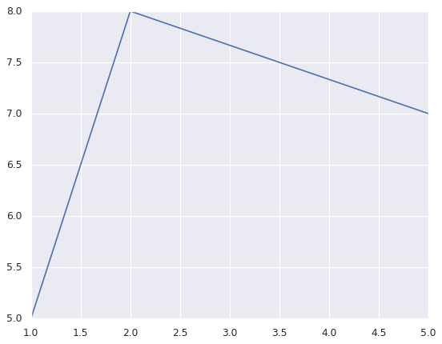

```python
plt.plot([1,2,5],[5,8,7])
plt.show()
```

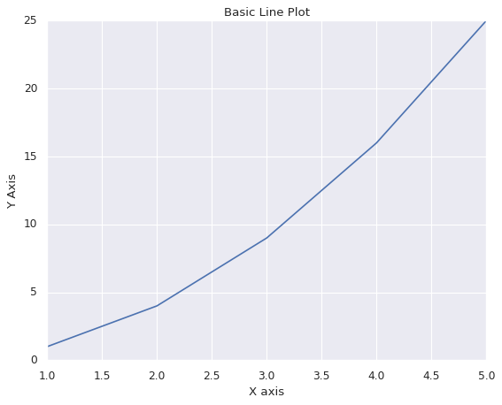

```python
x=[1,2,3,4,5]
y=[1,4,9,16,25]

##create a line plot
plt.plot(x,y)
plt.xlabel('X axis')
plt.ylabel('Y Axis')
plt.title("Basic Line Plot")
plt.show()
```

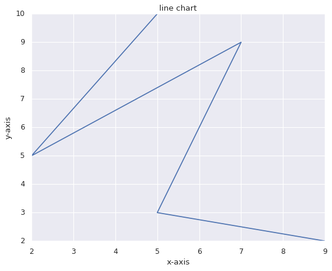

```python
x=[5,2,7,5,9]
y=[10,5,9,3,2]
plt.plot(x,y)
plt.title("line chart")
plt.xlabel("x-axis")
plt.ylabel("y-axis")
plt.show()
```

```python
import numpy as np
from matplotlib import pyplot as plt
x=np.arange(0,np.pi,0.1)
print(x)
```

```
[0.  0.1 0.2 0.3 0.4 0.5 0.6 0.7 0.8 0.9 1.  1.1 1.2 1.3 1.4 1.5 1.6 1.7
 1.8 1.9 2.  2.1 2.2 2.3 2.4 2.5 2.6 2.7 2.8 2.9 3.  3.1]
```

```python
y=np.sin(x)
print(y)
```

```
[0.         0.09983342 0.19866933 0.29552021 0.38941834 0.47942554
 0.56464247 0.64421769 0.71735609 0.78332691 0.84147098 0.89120736
 0.93203909 0.96355819 0.98544973 0.99749499 0.9995736  0.99166481
 0.97384763 0.94630009 0.90929743 0.86320937 0.8084964  0.74570521
 0.67546318 0.59847214 0.51550137 0.42737988 0.33498815 0.23924933
 0.14112001 0.04158066]
```

```
[0.  0.5 1.  1.5 2.  2.5 3.  3.5 4.  4.5 5.  5.5 6. ]
[ 0.          0.47942554  0.84147098  0.99749499  0.90929743  0.59847214
  0.14112001 -0.35078323 -0.7568025  -0.97753012 -0.95892427 -0.70554033
 -0.2794155 ]
```

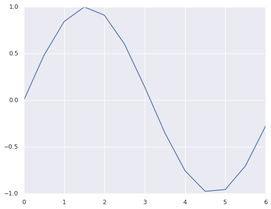

```python
x=np.arange(0,2*np.pi,0.5)
print(x)
y=np.sin(x)
print(y)
plt.plot(x,y)
plt.show()
```

```
[0.  0.1 0.2 0.3 0.4 0.5 0.6 0.7 0.8 0.9 1.  1.1 1.2 1.3 1.4 1.5 1.6 1.7
 1.8 1.9 2.  2.1 2.2 2.3 2.4 2.5 2.6 2.7 2.8 2.9 3.  3.1 3.2 3.3 3.4 3.5
 3.6 3.7 3.8 3.9 4.  4.1 4.2 4.3 4.4 4.5 4.6 4.7 4.8 4.9 5.  5.1 5.2 5.3
 5.4 5.5 5.6 5.7 5.8 5.9 6.  6.1 6.2]
[ 0.          0.09983342  0.19866933  0.29552021  0.38941834  0.47942554
  0.56464247  0.64421769  0.71735609  0.78332691  0.84147098  0.89120736
  0.93203909  0.96355819  0.98544973  0.99749499  0.9995736   0.99166481
  0.97384763  0.94630009  0.90929743  0.86320937  0.8084964   0.74570521
  0.67546318  0.59847214  0.51550137  0.42737988  0.33498815  0.23924933
  0.14112001  0.04158066 -0.05837414 -0.15774569 -0.2555411  -0.35078323
 -0.44252044 -0.52983614 -0.61185789 -0.68776616 -0.7568025  -0.81827711
 -0.87157577 -0.91616594 -0.95160207 -0.97753012 -0.993691   -0.99992326
 -0.99616461 -0.98245261 -0.95892427 -0.92581468 -0.88345466 -0.83226744
 -0.77276449 -0.70554033 -0.63126664 -0.55068554 -0.46460218 -0.37387666
 -0.2794155  -0.1821625  -0.0830894 ]
```

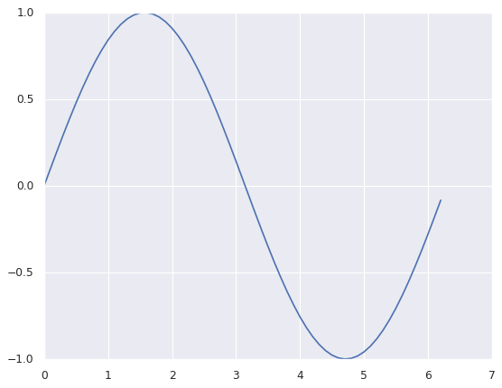

```python
x=np.arange(0,2*np.pi,0.1)
print(x)
y=np.sin(x)
print(y)
plt.plot(x,y)
plt.show()
```

```
[ 0.   0.1  0.2  0.3  0.4  0.5  0.6  0.7  0.8  0.9  1.   1.1  1.2  1.3
  1.4  1.5  1.6  1.7  1.8  1.9  2.   2.1  2.2  2.3  2.4  2.5  2.6  2.7
  2.8  2.9  3.   3.1  3.2  3.3  3.4  3.5  3.6  3.7  3.8  3.9  4.   4.1
  4.2  4.3  4.4  4.5  4.6  4.7  4.8  4.9  5.   5.1  5.2  5.3  5.4  5.5
  5.6  5.7  5.8  5.9  6.   6.1  6.2  6.3  6.4  6.5  6.6  6.7  6.8  6.9
  7.   7.1  7.2  7.3  7.4  7.5  7.6  7.7  7.8  7.9  8.   8.1  8.2  8.3
  8.4  8.5  8.6  8.7  8.8  8.9  9.   9.1  9.2  9.3  9.4  9.5  9.6  9.7
  9.8  9.9 10.  10.1 10.2 10.3 10.4 10.5 10.6 10.7 10.8 10.9 11.  11.1
 11.2 11.3 11.4 11.5 11.6 11.7 11.8 11.9 12.  12.1 12.2 12.3 12.4 12.5]
[ 1.          0.99500417  0.98006658  0.95533649  0.92106099  0.87758256
  0.82533561  0.76484219  0.69670671  0.62160997  0.54030231  0.45359612
  0.36235775  0.26749883  0.16996714  0.0707372  -0.02919952 -0.12884449
 -0.22720209 -0.32328957 -0.41614684 -0.5048461  -0.58850112 -0.66627602
 -0.73739372 -0.80114362 -0.85688875 -0.90407214 -0.94222234 -0.97095817
 -0.9899925  -0.99913515 -0.99829478 -0.98747977 -0.96679819 -0.93645669
 -0.89675842 -0.84810003 -0.79096771 -0.7259323  -0.65364362 -0.57482395
 -0.49026082 -0.40079917 -0.30733287 -0.2107958  -0.11215253 -0.01238866
  0.08749898  0.18651237  0.28366219  0.37797774  0.46851667  0.55437434
  0.63469288  0.70866977  0.77556588  0.83471278  0.88551952  0.92747843
  0.96017029  0.98326844  0.9965421   0.99985864  0.99318492  0.97658763
  0.95023259  0.91438315  0.86939749  0.8157251   0.75390225  0.68454667
  0.60835131  0.52607752  0.43854733  0.34663532  0.25125984  0.15337386
  0.05395542 -0.04600213 -0.14550003 -0.24354415 -0.33915486 -0.43137684
 -0.51928865 -0.6020119  -0.67872005 -0.74864665 -0.81109301 -0.86543521
 -0.91113026 -0.9477216  -0.97484362 -0.99222533 -0.99969304 -0.99717216
 -0.98468786 -0.96236488 -0.93042627 -0.88919115 -0.83907153 -0.78056818
 -0.71426565 -0.64082642 -0.56098426 -0.47553693 -0.38533819 -0.29128928
 -0.19432991 -0.09542885  0.0044257   0.10423603  0.20300486  0.29974534
  0.39349087  0.48330476  0.56828963  0.64759634  0.72043248  0.7860703
  0.84385396  0.89320611  0.93363364  0.96473262  0.9861923   0.99779828]
```

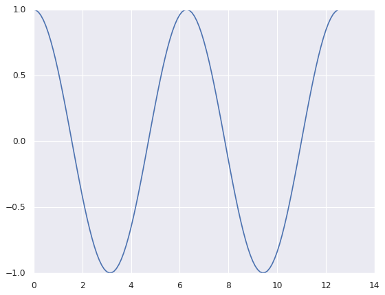

```python
x=np.arange(0,4*np.pi,0.1)
print(x)
y=np.cos(x)
print(y)
plt.plot(x,y)
plt.show()
```

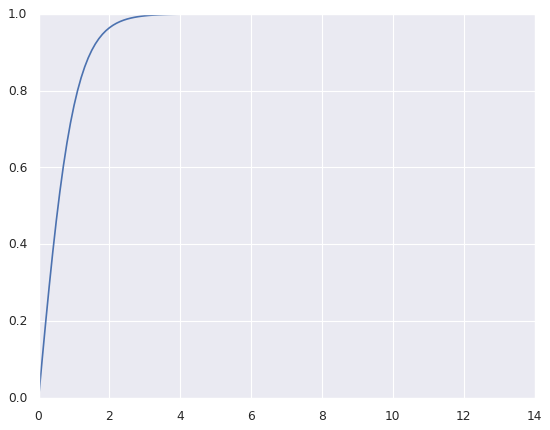

```python
x=np.arange(0,4*np.pi,0.1)
#print(x)
y=np.tanh(x)
#print(y)
plt.plot(x,y)
plt.show()
```

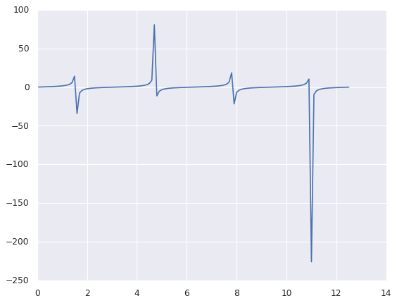

```python
x=np.arange(0,4*np.pi,0.1)
#print(x)
y=np.tan(x)
#print(y)
plt.plot(x,y)
plt.show()
```

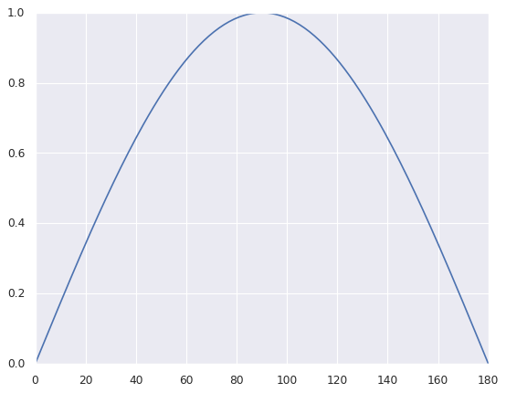

```python
degrees=np.arange(0,181)
sine=np.sin(np.radians(degrees))
plt.plot(degrees, sine)
plt.show()
#print(degrees)
#print(sine)
```

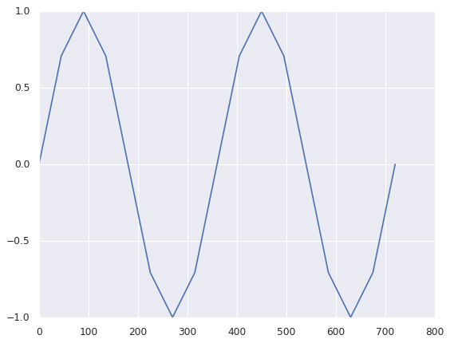

```python
degrees=np.arange(0,721,45)
sine=np.sin(np.radians(degrees))
plt.plot(degrees,sine)
plt.show()
```

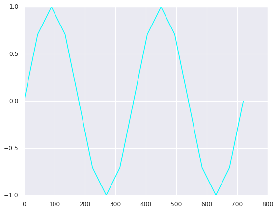

```python
degrees=np.arange(0,721,45)
sine=np.sin(np.radians(degrees))
plt.plot(degrees,sine,c="cyan") # changing the color of line
plt.show()
```

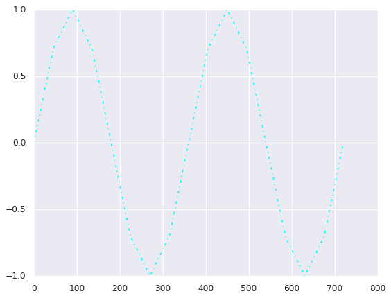

```python
# Line color and pattern change
degrees=np.arange(0,721,45)
sine=np.sin(np.radians(degrees))
plt.plot(degrees,sine,c="cyan",ls="dashdot") #ls= line state or line style. c= color of the line in graph.
plt.show()
```

```
[   5    8   29   86  197  380  653 1034 1541 2192 3005]
```

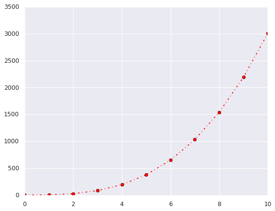

```python
x=np.arange(0,11)
y=3*x**2*x+5
print(y)
plt.plot(x,y,marker="o",c="red",ls="dashdot")
plt.show()
```

We can plot more than one line into line chart, we can also make it colourful

# Markers

‘.’ – point marker, ‘o’- circle, ‘*’- star, ‘^’- triangle_up, ‘p’- pentagon, ‘s’- square, ‘+’-plus, ‘D’- Diamond, ‘|’- vline …. And many more.

# Colors

‘b’ -blue , ‘g’- green , ‘r’-red , ‘y’- yellow , ‘k’- black , ‘m’- magenta, ‘w’- white, ‘c’- cyan

# Line styles

‘-‘ (solid line), ‘- -‘ (Dashed line) , ‘-.’ (Dash dot line) , ‘:’ (Dotted line)

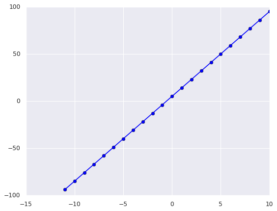

```python
x=np.arange(-11,11)
y=3*x+6*x+5
plt.plot(x,y,marker="o",c="blue")
plt.show()
```

# Creating a multi line graph

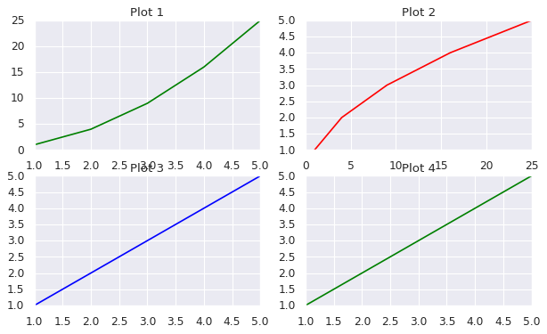

```python
## Multiple Plots
## Sample data
x = [1, 2, 3, 4, 5]
y1 = [1, 4, 9, 16, 25]
y2 = [1, 2, 3, 4, 5]

plt.figure(figsize=(9,5))

plt.subplot(2,2,1)
plt.plot(x,y1,color='green')
plt.title("Plot 1")

plt.subplot(2,2,2)
plt.plot(y1,x,color='red')
plt.title("Plot 2")

plt.subplot(2,2,3)
plt.plot(x,y2,color='blue')
plt.title("Plot 3")

plt.subplot(2,2,4)
plt.plot(x,y2,color='green')
plt.title("Plot 4")
```

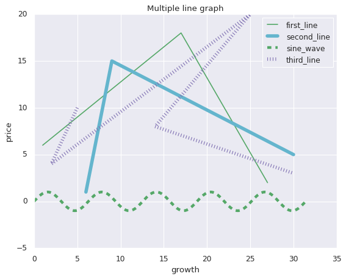

```python
import math
x1=[1,17,27]
y1=[6,18,2]
x2=[6,9,30]
y2=[1,15,5]
x3=[5,2,25,14,30]
y3=[10,4,20,8,3]
x=np.arange(0,math.pi*10,0.10)
y=np.sin(x)
plt.plot(x1,y1,"g",label="first_line")
plt.plot(x2,y2,"c",label="second_line",linewidth=5)
plt.plot(x,y,"g--",label="sine_wave",linewidth=4)
plt.plot(x3,y3,"m:",label="third_line",linewidth=5)
plt.title("Multiple line graph")
plt.xlabel("growth")
plt.ylabel("price")
plt.legend()
plt.show()
```

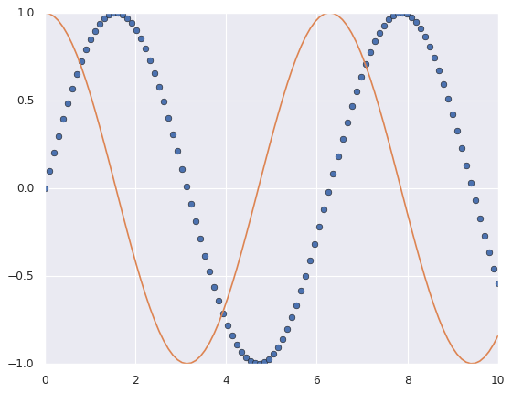

```python
x=np.linspace(0,10,100) #will create an array of 100 values with spaced between 1 and 10
plt.plot(x,np.sin(x),"o")
plt.plot(x,np.cos(x),"-")
plt.show()
```

# Bar Plot or Bar Graph

- Bar plot or Bar gharph or Bar Graph
- It is a graphichal dispaly of data using rectangular bar of diferent heights.

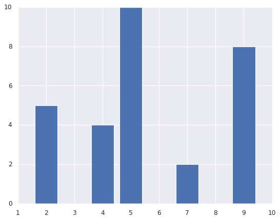

```python
from matplotlib import pyplot as plt
x=[5,2,9,4,7]
y=[10,5,8,4,2]
plt.bar(x,y)
plt.show()
```

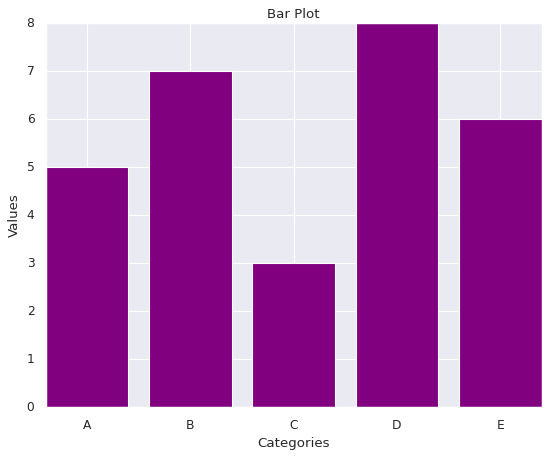

```python
categories=['A','B','C','D','E']
values=[5,7,3,8,6]

##create a bar plot
plt.bar(categories,values,color='purple')
plt.xlabel('Categories')
plt.ylabel('Values')
plt.title('Bar Plot')
plt.show()
```

```python
#relational plots, distributed plots and categorical plot
#under relational plot we have line plot and scatter plot
```

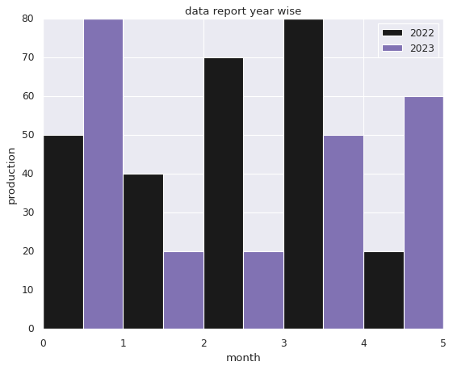

```python
plt.bar([0.25,1.25,2.25,3.25,4.25],[50,40,70,80,20],label="2022",color="k",width=0.5) # random data
plt.bar([0.75,1.75,2.75,3.75,4.75],[80,20,20,50,60],label="2023",color="m",width=0.5) # random data
plt.legend()
plt.xlabel("month")
plt.ylabel("production")
plt.title("data report year wise")
plt.show()
```

# Creating Sub Plots

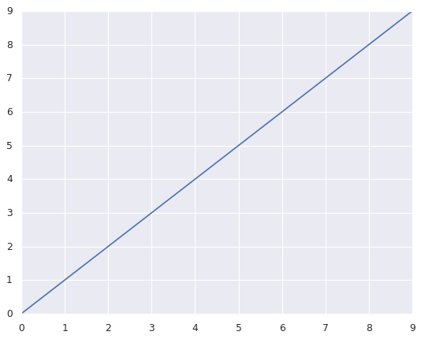

```python
from matplotlib import pyplot as plt
import seaborn as sns
import numpy as np
import pandas as pd
data=np.arange(10)
plt.plot(data)
plt.show()
```

```python
#figure and subplots
fig=plt.figure()
plt.show()
```

```python
p1=fig.add_subplot(2,2,1) #creating four subplot in the fig
p2=fig.add_subplot(2,2,2)
p3=fig.add_subplot(2,2,3)
p4=fig.add_subplot(2,2,4)
```

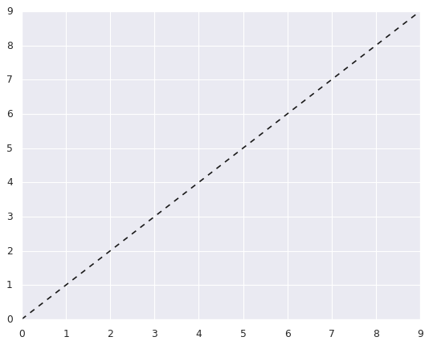

```python
plt.plot(np.arange(10),"k--") #plot function only
p1.scatter(np.arange(30),np.arange(30)+np.random.randn(30))
```

```
[[<Axes: > <Axes: >]
 [<Axes: > <Axes: >]]
```

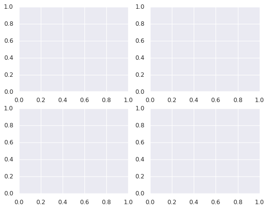

```python
fig,axes=plt.subplots(2,2)
print(axes)
```

```
Axes(0.125,0.1;0.775x0.8)
```

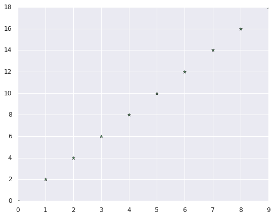

```python
fig,p=plt.subplots(1,1)
print(p)
x=np.arange(10)
y=np.arange(10)*2
plt.plot(x,y,"g*")
plt.show()
```

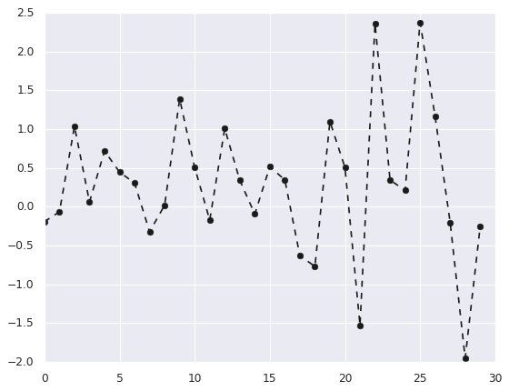

```python
fig,p=plt.subplots(1,1)
plt.plot(np.random.randn(30),"ko--",label="one")
plt.show()
```

# Setting labels and legends

```python
p.set_xlabel("xaxis")
p.set_ylabel("yaxis")
p.set_title("myplot")
p.legend(loc="best") #search automatically according to its best loaction
```

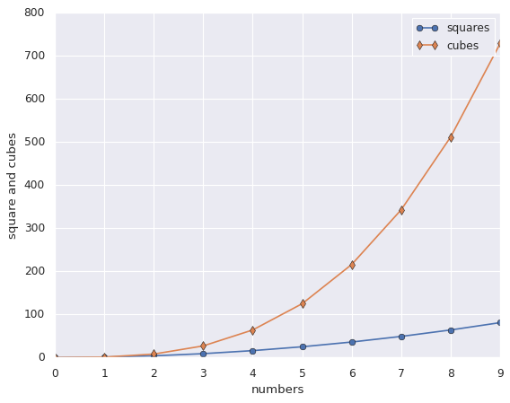

```python
#two plots inside a figure
plt.figure()
x=np.arange(10)
y=x**2
z=x**3
plt.plot(y,"o-",z,"-d")
plt.xlabel("numbers")
plt.ylabel("square and cubes")
plt.legend(["squares","cubes"])
plt.show()
```

# Scatter plot

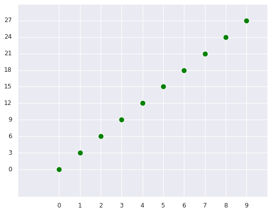

```python
plt.figure()
x=np.arange(10)
y=np.arange(10)*3
plt.scatter(x,y,s=100,c="green") #sample =s size of the bullets
plt.xticks(np.arange(0,10,1)) # ticks
plt.yticks(np.arange(0,30,3))
plt.show()
```

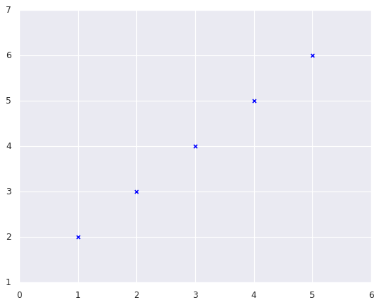

```python
x = [1, 2, 3, 4, 5]
y = [2, 3, 4, 5, 6]

plt.scatter(x,y,color="blue",marker='x')
```

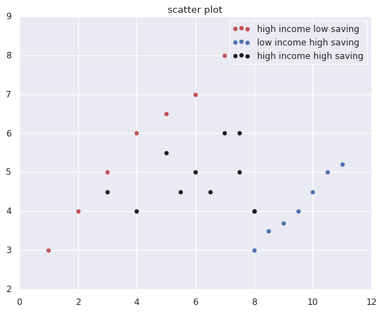

```python
plt.figure()
x=[1,2,3,4,5,6,7]
y=[3,4,5,6,6.5,7,8]
x1=[8,8.5,9,9.5,10,10.5,11]
y1=[3,3.5,3.7,4,4.5,5,5.2]
x2=[4,3,6,7,7.5,8,6.5,8,7.5,5,5.5]
y2=[4,4.5,5,6,5,4,4.5,4,6,5.5,4.5]
plt.scatter(x,y,label="high income low saving",color="r")
plt.scatter(x1,y1,label="low income high saving",color="b")
plt.scatter(x2,y2,label="high income high saving", color="k")
plt.title("scatter plot")
plt.legend()
plt.show()
```

[output not shown]

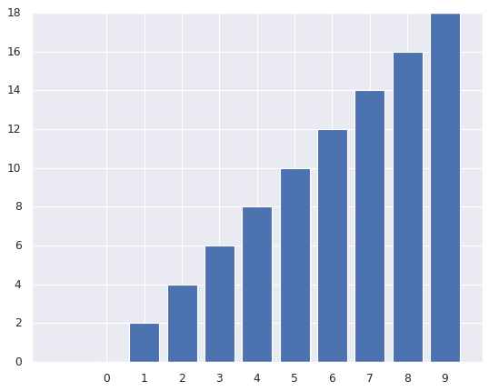

```python
plt.figure()
x = np.arange(10)
y = x * 2
plt.bar(x,y,width = 0.8)
plt.xticks(x)
plt.yticks(y)
```

[output not shown]

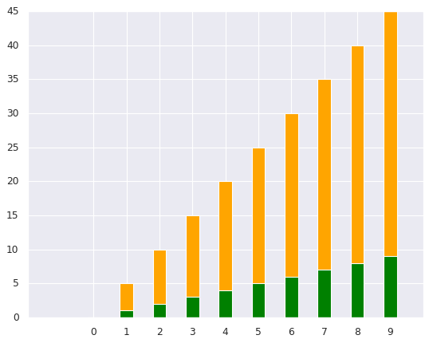

```python
plt.figure()
z = x * 4
plt.bar(x,y,width = 0.4,color = 'green')
plt.bar(x,z,width = 0.4,bottom = x,color = 'orange')
plt.xticks(x)
```

```
<BarContainer object of 10 artists>
```

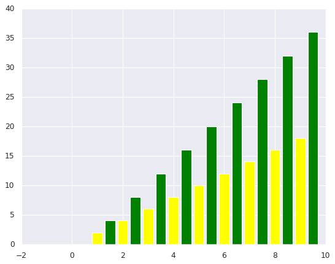

```python
plt.figure()
x = np.arange(10)
y = x * 2
plt.bar(x,y,width = 0.4,color = 'yellow')
plt.bar(x+0.5,y*2,width = 0.4,color='green')
```

#### Histograms

- Histograms are used to represent the distribution of a dataset. They divide the data into bins and count the number of data points in each bin.
- This is a graphical representation of numerical data and it is graphing tool that summarises discreate and continous data.
- Histogram are used to illustrate the major features of the distributuion of data.
- Histogram is a graph tha shows thee frequency of numerical data using rectangles.